# Tarea2-Ejercicio 4

Varios

2025-05-13

# Modelos No Paramétricos y de Regresión

Primeramente definirimos directorios y leeremos la base $Tar2-4A$ brindada.

```r
#Limpiemos los datos de R
rm(list = ls(all.names = TRUE))
gc()
```

```
##          used (Mb) gc trigger (Mb) max used (Mb)
## Ncells 540071 28.9    1199831 64.1   686457 36.7
## Vcells 988331  7.6    8388608 64.0  1876755 14.4
```

```r
#Obtenemos el directorio
directorio <- getwd() #Se espera que la base este en la carpeta en la que se esta trabajando

#Establezcamos directorios

setwd(directorio)
#Importamos la base
base <- "Tar2-4A.csv"
data <- read.csv(base)
```

Hagamos un análisis a las variables que conforman nuestro data.

```r
str(data)
```

```
## 'data.frame':    120 obs. of  3 variables:
##  $ Sexo   : chr  "Hombre" "Hombre" "Hombre" "Hombre" ...
##  $ Trat   : chr  "Control" "Control" "Control" "Control" ...
##  $ Puntaje: num  12.22 9.99 12.83 14.38 11.12 ...
```

**I. Realice un análisis descriptivo de los datos. Dado que las dos covariables son categóricas, incluya un boxplot para cada posible combinación de niveles que se pueden observar en esas dos variables categóricas $(boxplot(Puntaje~Trat+Sexo, . . . ))$. Comente lo que observe.**

Dado que trabajamos con variables categóricas, necesitaremos transformar las variables $Sexo$ y $Trat$ a variables tipo *factor*.

```r
data$Sexo <- factor(data$Sexo)
data$Trat <- factor(data$Trat)

str(data) #Una pequeña verificacion
```

```
## 'data.frame':    120 obs. of  3 variables:
##  $ Sexo   : Factor w/ 2 levels "Hombre","Mujer": 1 1 1 1 1 1 1 1 1 1 ...
##  $ Trat   : Factor w/ 3 levels "Control","Trat1",..: 1 1 1 1 1 1 1 1 1 1 ...
##  $ Puntaje: num  12.22 9.99 12.83 14.38 11.12 ...
```

```r
levels(data$Sexo)
```

```
## [1] "Hombre" "Mujer"
```

```r
levels(data$Trat)
```

```
## [1] "Control" "Trat1"   "Trat2"
```

Realicemos los $Box-plot$:

Primero veamos comos se comporta el tratamiento solo respecto al *sexo*:

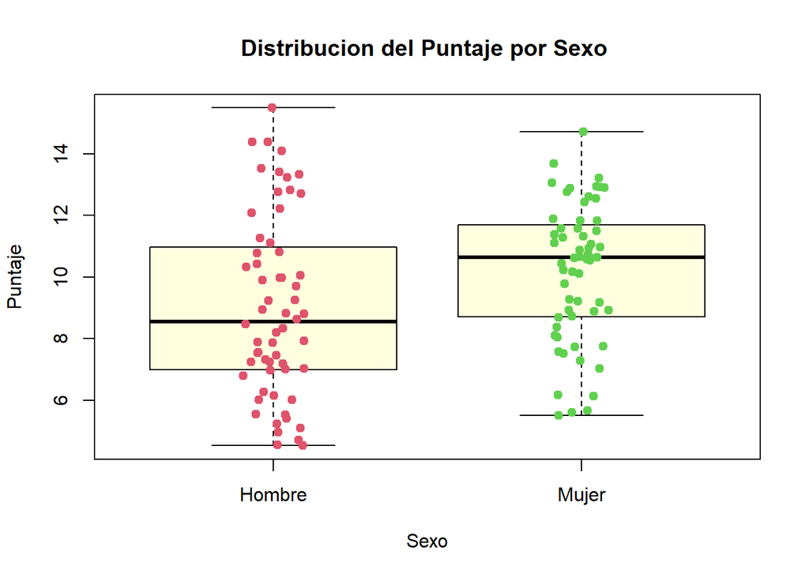

```r
boxplot(Puntaje ~ Sexo, data = data,
        col = "lightyellow",
        main = "Distribucion del Puntaje por Sexo ")
stripchart(Puntaje ~ Sexo, data = data,
           method = "jitter",
           pch = 19,
           col = 2:4,
           vertical = TRUE,
           add = TRUE)
```

Respecto al sexo, notemos que realmente no hay mucha diferencia respecto al puntaje que se obtiene, si bien, el de las mujeres tiene una varianza ligeramente mas pequeña, las medias en puntaje no distan exhorbitadamente una de otra, por lo que, nos podría llevar a pensar que el sexo no impacta directamente en el puntaje.

Veamos comos se comporta el tratamiento solo respecto al *tratamiento* (contro, Trat1, Trat2):

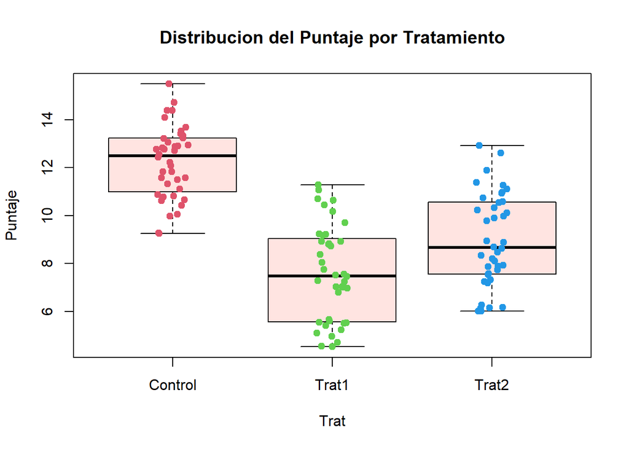

```r
boxplot(Puntaje ~ Trat , data = data,
        col = "mistyrose",
        main = "Distribucion del Puntaje por Tratamiento")
stripchart(Puntaje ~ Trat, data = data,
           method = "jitter",
           pch = 19,
           col = 2:4,
           vertical = TRUE,
           add = TRUE)
```

Ahora analizando solamente el tratamiento, notemos que sus varianzas en los distintos niveles son muy similares, exceptuando la de *Control* , aquí si hay una diferencia más significativa respecto las medias y es evidente que la de la variable *Control* es la mas alta. Las medias de las variables *Trat1* y *Trat2* son muy parecidas entre sí y además son mucho más pequeñas que las de *Control*.

Finalmente realicemos un análisis respecto el *tratamiento y el sexo* sobre el puntaje.

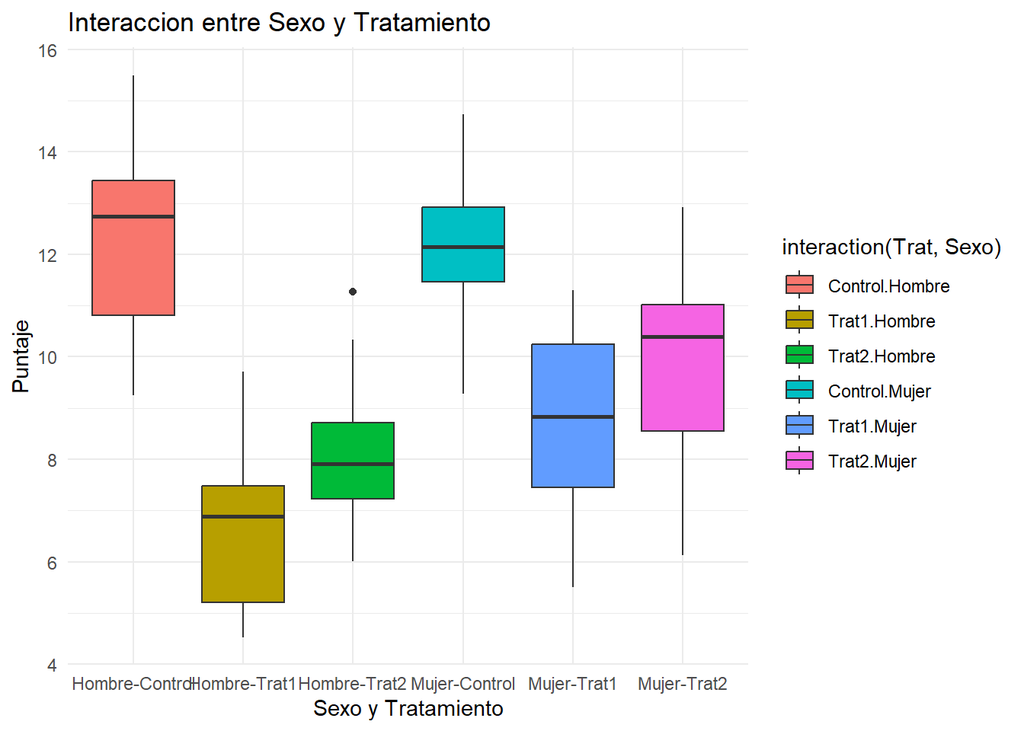

```r
# Cargar la librería ggplot2
library(ggplot2)

# Crear el boxplot
ggplot(data, aes(x = interaction(Trat, Sexo), y = Puntaje, fill = interaction(Trat, Sexo))) +
  geom_boxplot() +
  labs(x = "Sexo y Tratamiento", y = "Puntaje", title = "Interaccion entre Sexo y Tratamiento") +
  theme_minimal() +
  scale_x_discrete(labels = c("Hombre-Control", "Hombre-Trat1", "Hombre-Trat2", "Mujer-Control", "Mujer-Trat1", "Mujer-Trat2")) # Si tienes 3 niveles de Trat y 2 de Sexo
```

Notemos que al considerar ambas variables en conjunto se obtienen resultados interesantes.

**II. Considerando un modelo de regresión que incluye las dos variables categóricas de forma individual y también su interacción, dé la expresión del puntaje promedio para cada valor de las variables categóricas, es decir: $E(puntaje; T rat = k, Sexo = l)$, con $k \in \{Control, T rat1, T rat2\}$ y $l \in \{Hombre, Mujer\}$; así como la estimación puntual correspondiente.**

```r
# Considerando las variables de manera individual
fitT = lm(Puntaje ~ Trat, data = data)
fitS = lm(Puntaje ~ Sexo, data = data)

# Considerando su interacción
fit1 = lm(Puntaje ~ Trat*Sexo, data = data)
```

Consideremos primeramente el análisis con las variables de manera individual:

**Tratamiento**

```r
# Con el tratamiento
summary(fitT)
```

```
##
## Call:
## lm(formula = Puntaje ~ Trat, data = data)
##
## Residuals:
##     Min      1Q  Median      3Q     Max
## -3.0801 -1.4149 -0.0864  1.3026  3.9506
##
## Coefficients:
##             Estimate Std. Error t value Pr(>|t|)
## (Intercept)  12.2315     0.2871   42.60  < 2e-16 ***
## TratTrat1    -4.6224     0.4060  -11.38  < 2e-16 ***
## TratTrat2    -3.2645     0.4060   -8.04 8.11e-13 ***
## ---
## Signif. codes:  0 '***' 0.001 '**' 0.01 '*' 0.05 '.' 0.1 ' ' 1
##
## Residual standard error: 1.816 on 117 degrees of freedom
## Multiple R-squared:  0.5393, Adjusted R-squared:  0.5314
## F-statistic: 68.48 on 2 and 117 DF,  p-value: < 2.2e-16
```

Estamos considerando una sola variable categórica (la de Tratamiento), y el nivel de referencia considerado es el de la variable *Control*, tendremos:

$$\mathbb{E} [Puntaje|Trat=k]= \beta_0 + \beta_1 *Trat1 + \beta_2 *Trat2$$
Tendremos:

Para $Trat=Control$:

$$\mathbb{E} [Puntaje|Trat=Control]= \beta_0$$
pues $Trat1=0$ y $Trat2=0$.

Con un análisis similar tendremos:

Para $Trat=Trat1$:
$$\mathbb{E} [Puntaje|Trat=Trat1]= \beta_0 + \beta_1 *Trat1$$

Para $Trat=Trat2$:
$$\mathbb{E} [Puntaje|Trat=Trat2]= \beta_0 + \beta_2 *Trat2$$

Y sus respectivas estimaciones puntales dadas por el *modelo ajustado* y el **summary** son:

$$\mathbb{E} [Puntaje|Trat=Control]= \beta_0 = 12.2315$$

$$\mathbb{E} [Puntaje|Trat=Trat1]= \beta_0 + \beta_1 *Trat1 = 12.2315
-4.6224 = 7.6091$$

$$\mathbb{E} [Puntaje|Trat=Trat2]= \beta_0 + \beta_2 *Trat2 = 12.2315 -
3.2645 = 8.967$$

```r
# Con el tratamiento
summary(fitT)
```

```
##
## Call:
## lm(formula = Puntaje ~ Trat, data = data)
##
## Residuals:
##     Min      1Q  Median      3Q     Max
## -3.0801 -1.4149 -0.0864  1.3026  3.9506
##
## Coefficients:
##             Estimate Std. Error t value Pr(>|t|)
## (Intercept)  12.2315     0.2871   42.60  < 2e-16 ***
## TratTrat1    -4.6224     0.4060  -11.38  < 2e-16 ***
## TratTrat2    -3.2645     0.4060   -8.04 8.11e-13 ***
## ---
## Signif. codes:  0 '***' 0.001 '**' 0.01 '*' 0.05 '.' 0.1 ' ' 1
##
## Residual standard error: 1.816 on 117 degrees of freedom
## Multiple R-squared:  0.5393, Adjusted R-squared:  0.5314
## F-statistic: 68.48 on 2 and 117 DF,  p-value: < 2.2e-16
```

**Sexo**

```r
# Con el tratamiento
summary(fitS)
```

```
##
## Call:
## lm(formula = Puntaje ~ Sexo, data = data)
##
## Residuals:
##     Min      1Q  Median      3Q     Max
## -4.6858 -1.8576  0.1295  1.6570  6.4835
##
## Coefficients:
##             Estimate Std. Error t value Pr(>|t|)
## (Intercept)   9.0123     0.3352   26.89   <2e-16 ***
## SexoMujer     1.1805     0.4740    2.49   0.0142 *
## ---
## Signif. codes:  0 '***' 0.001 '**' 0.01 '*' 0.05 '.' 0.1 ' ' 1
##
## Residual standard error: 2.596 on 118 degrees of freedom
## Multiple R-squared:  0.04993,    Adjusted R-squared:  0.04188
## F-statistic: 6.201 on 1 and 118 DF,  p-value: 0.01416
```

Haciendo un proceso muy similar al que se realizó con la variable **Trat**, sin embargo, aquí solo hay dos niveles de la variable por lo que se considera a *Hombre* como nivel de referencia (alfábeticamente $R$ los considera):

$$\mathbb{E} [Puntaje|Sexo=l]= \beta_0 + \beta_1 *Mujer$$
Tendremos:

Para $Sexo=Hombre$:

$$\mathbb{E} [Puntaje|Sexo=Hombre]= \beta_0$$

Para $Sexo=Mujer$:
$$\mathbb{E} [Puntaje|Sexo=Mujer]= \beta_0 + \beta_1 *Mujer$$

Y sus respectivas estimaciones puntales dadas por el *modelo ajustado* y el **summary** son:

$$\mathbb{E} [Puntaje|Sexo=Hombre]= \beta_0 = 9.0123$$

$$\mathbb{E} [Puntaje|Sexo=Mujer]= \beta_0 + \beta_1 *Mujer = 9.0123 +
1.1805 = 10.1928$$

Finalmente veamos lo que sucede al considerar la **interacción entre ambas variables**.

```r
# Con el tratamiento
summary(fit1)
```

```
##
## Call:
## lm(formula = Puntaje ~ Trat * Sexo, data = data)
##
## Residuals:
##     Min      1Q  Median      3Q     Max
## -3.7283 -1.2315  0.2594  1.0044  3.1938
##
## Coefficients:
##                     Estimate Std. Error t value Pr(>|t|)
## (Intercept)          12.3482     0.3709  33.289  < 2e-16 ***
## TratTrat1            -5.7357     0.5246 -10.934  < 2e-16 ***
## TratTrat2            -4.2720     0.5246  -8.143 5.41e-13 ***
## SexoMujer            -0.2334     0.5246  -0.445  0.65720
## TratTrat1:SexoMujer   2.2267     0.7419   3.001  0.00330 **
## TratTrat2:SexoMujer   2.0150     0.7419   2.716  0.00764 **
## ---
## Signif. codes:  0 '***' 0.001 '**' 0.01 '*' 0.05 '.' 0.1 ' ' 1
##
## Residual standard error: 1.659 on 114 degrees of freedom
## Multiple R-squared:  0.6253, Adjusted R-squared:  0.6089
## F-statistic: 38.05 on 5 and 114 DF,  p-value: < 2.2e-16
```

Aquí sucede algo un poco distinto, pues al tener dos variables categóricas y dado que estamos considerando su interacción, necesitamos considerar 2 niveles de referencia, lo que usará $R$ nuevamente alfabéticamente serán *Control* y *Hombre*, de esta manera se tiene que:

$$\mathbb{E} [Puntaje|Trat=k,Sexo=l]= \beta_0 + \beta_1 * Trat1 + \beta_2
* Trat2 + \beta_3 * Mujer +
\beta_4 (Trat1*Mujer) + \beta_5 (Trat2*Mujer)$$

Para $Trat=Control$ y $Sexo=Hombre$:

$$\mathbb{E} [Puntaje|Trat=Control,Sexo=Hombre]= \beta_0$$

Para $Trat=Control$ y $Sexo=Mujer$:

$$\mathbb{E} [Puntaje|Trat=Control,Sexo=Mujer]= \beta_0 + \beta_3 * Mujer
= \beta_0 + \beta_3$$

Para $Trat=Trat1$ y $Sexo=Hombre$:

$$\mathbb{E} [Puntaje|Trat=Trat1,Sexo=Hombre]= \beta_0 + \beta_1 * Trat1 =
\beta_0 + \beta_1$$

Para $Trat=Trat1$ y $Sexo=Mujer$:

$$\mathbb{E} [Puntaje|Trat=Trat1,Sexo=Mujer]= \beta_0 + \beta_1 * Trat1 +
\beta_3 * Mujer +
\beta_4 (Trat1*Mujer) = \beta_0 + \beta_1 + \beta_3 + \beta_4$$

Para $Trat=Trat2$ y $Sexo=Hombre$:

$$\mathbb{E} [Puntaje|Trat=Trat2,Sexo=Hombre]= \beta_0 + \beta_2 *
Trat2 = \beta_0 + \beta_2$$

Para $Trat=Trat2$ y $Sexo=Mujer$:

$$\mathbb{E} [Puntaje|Trat=Trat2,Sexo=Mujer]= \beta_0 + \beta_2 * Trat2 +
\beta_3 * Mujer + \beta_5 (Trat2*Mujer) = \beta_0 + \beta_2 + \beta_3 +
\beta_5$$

Sus respectivas estimaciones puntuales serán, dado el **summary** del modelo:

$$\mathbb{E} [Puntaje|Trat=Control,Sexo=Hombre]= \beta_0 = 12.3482$$

$$\mathbb{E} [Puntaje|Trat=Control,Sexo=Mujer]= \beta_0 + \beta_3 =
12.3482 -0.2334=12.1148$$

$$\mathbb{E} [Puntaje|Trat=Trat1,Sexo=Hombre]= \beta_0 + \beta_1 = 12.3482
-5.7357=6.6125$$

$$\mathbb{E} [Puntaje|Trat=Trat1,Sexo=Mujer] = \beta_0 + \beta_1 + \beta_3
+ \beta_4 = 12.3482-5.7357-0.2334+2.2267 =8.6058$$

$$\mathbb{E} [Puntaje|Trat=Trat2,Sexo=Hombre]= \beta_0 + \beta_2 =12.3482
-4.2720 = 8.0762$$

$$\mathbb{E} [Puntaje|Trat=Trat2,Sexo=Mujer] = \beta_0 + \beta_2 + \beta_3
+ \beta_5 = 12.3482-4.2720-0.2334+2.0150=9.8578$$

**III. Escriba las hipótesis que se contrastan con la tabla ANOVA, calcule ésta e interprete. Use α = .05.**

Veamos primeramente el código:

```r
anova(fit1)
```

```
## Analysis of Variance Table
##
## Response: Puntaje
##            Df Sum Sq Mean Sq F value    Pr(>F)
## Trat        2 451.56 225.779  82.043 < 2.2e-16 ***
## Sexo        1  41.81  41.806  15.191 0.0001644 ***
## Trat:Sexo   2  30.21  15.105   5.489 0.0052975 **
## Residuals 114 313.72   2.752
## ---
## Signif. codes:  0 '***' 0.001 '**' 0.01 '*' 0.05 '.' 0.1 ' ' 1
```

```r
print("Usando drop1")
```

```
## [1] "Usando drop1"
```

```r
drop1(fit1, test = "F")
```

```
## Single term deletions
##
## Model:
## Puntaje ~ Trat * Sexo
##           Df Sum of Sq    RSS    AIC F value   Pr(>F)
## <none>                 313.72 127.32
## Trat:Sexo  2    30.211 343.93 134.35   5.489 0.005298 **
## ---
## Signif. codes:  0 '***' 0.001 '**' 0.01 '*' 0.05 '.' 0.1 ' ' 1
```

Tenemos varia información pero en particular se nos brinda información sobre ciertas prueba de hipótesis relacionadas con el *tratamiento*, el *sexo* y la *interacción entre el tratamiento y el sexo*.

De manera precisa las hipótesis que se están comparando son:

Para el *Tratamiento*:

$$\begin{array}{ll}
\begin{align*}
H_{0}:=\ & \mathbb{E} [Puntaje|Trat=Control] = \mathbb{E}
[Puntaje|Trat=Trat1] = \mathbb{E} [Puntaje|Trat=Trat2] \\
H_{1}:=\ & \text{Al menos alguna media distinta.}
\end{align*}
\end{array}$$

Esto es equivalente a:

Para el *Sexo*:

$$\begin{array}{ll}
\begin{align*}
H_{0}:=\ & \mathbb{E} [Puntaje|Sexo=Hombre] = \mathbb{E}
[Puntaje|Sexo=Mujer] \\
H_{1}:=\ & \text{Tienen distinta media.}
\end{align*}
\end{array}$$

Esto es equivalente a tener:

$$\begin{array}{ll}
\begin{align*}
H_{0}:=\ & \beta_0 = \beta_0 + \beta_1 \Leftrightarrow \beta_1=0 \\
H_{1}:=\ & \text{Tienen distinta media.}\ \Leftrightarrow \ \beta_1
\neq 0
\end{align*}
\end{array}$$

Finalmente para la *interacción*:

$$\begin{array}{ll}
\begin{align*}
H_{0}:=\ & \mathbb{E} [Puntaje|Trat=k, Sexo=Hombre] = \mathbb{E}
[Puntaje|Trat=k, Sexo=Mujer] \ \ \ ,\forall k \in \{Control, T rat1, T
rat2\} \\
H_{1}:=\ & \exists k, \text{ t.q } [Puntaje|Trat=k, Sexo=Hombre]
\neq \mathbb{E} [Puntaje|Trat=k, Sexo=Mujer] \\
& \text{i.e Al menos uno tiene distinta media.}
\end{align*}
\end{array}$$

De la tabla anova tenemos que para la prueba hipótesis sobre el **Tratamiento**, tenemos un $p-value<2.2e-16$, es decir, que alguno de los tratamientos es significativo para el Puntaje (se rechaza la hipótesis nula).

Para el **Sexo** tenemos un $p-value<0.0001644$, es decir, que dependiendo del sexo se tienen distintos Puntajes y por ende esta variable aporta información que se debería de considerar en el modelo (se rechaza la hipótesis nula).

Finalmente cuando hablamos de la interacción entre **Tratamiento-Sexo**, se obtiene un $p-value<0.0052975$, es decir, también tenemos significancia al considerar la interacción entre ambas variables, por lo que es importante considerar esto en el modelo que estamos planteando.

**IV. ¿Se puede considerar que el sexo tiene un efecto en el puntaje, es decir, al menos para un tratamiento existe un efecto diferenciado en el puntaje derivado del sexo de los individuos? Use una prueba $F$ con $\alpha$ = .025. Interprete.**

En la prueba ANOVA vimos que hay significancia veamos que sucede usando una prueba $F$:

```r
drop1(fit1, test = "F")
```

```
## Single term deletions
##
## Model:
## Puntaje ~ Trat * Sexo
##           Df Sum of Sq    RSS    AIC F value   Pr(>F)
## <none>                 313.72 127.32
## Trat:Sexo  2    30.211 343.93 134.35   5.489 0.005298 **
## ---
## Signif. codes:  0 '***' 0.001 '**' 0.01 '*' 0.05 '.' 0.1 ' ' 1
```

Queremos verificar si:

$$\begin{array}{ll}
\begin{align*}
H_{0}:=\ & \mathbb{E} [Puntaje|Trat=k, Sexo=Hombre] = \mathbb{E}
[Puntaje|Trat=k, Sexo=Mujer] \ \ \ ,\forall k \in \{Control, T rat1, T
rat2\} \\
H_{1}:=\ & \exists k, \text{ t.q } [Puntaje|Trat=k, Sexo=Hombre]
\neq \mathbb{E} [Puntaje|Trat=k, Sexo=Mujer] \\
& \text{i.e Al menos uno tiene distinta media.}
\end{align*}
\end{array}$$

Ahora para las pruebas simultaneas, veamos para que tratamiento se puede considerar que el sexo tiene un efecto.

Para esto dado el modelo:

$$\mathbb{E} [Puntaje|Trat=k,Sexo=l]= \beta_0 + \beta_1 * Trat1 + \beta_2
* Trat2 + \beta_3 * Mujer +
\beta_4 (Trat1*Mujer) + \beta_5 (Trat2*Mujer)$$

Queremos verificar para que tratamientos en específico el sexo tiene significancia, en términos de prueba de hipótesis, queremos comparar:

Para **Control**:
$$\mathbb{E} [Puntaje|Trat=Control,Sexo=Hombre]= \beta_0$$

$$\mathbb{E} [Puntaje|Trat=Control,Sexo=Mujer]= \beta_0 + \beta_3$$

Para ver si hay significancia se realiza la pueba:
$$H_0:=\beta_3=0 \ \ vs\ \ H_a:=\beta_3 \neq 0$$

Para **Trat1**:

$$\mathbb{E} [Puntaje|Trat=Trat1,Sexo=Hombre]= \beta_0 + \beta_1$$

$$\mathbb{E} [Puntaje|Trat=Trat1,Sexo=Mujer]= \beta_0 + \beta_1 + \beta_3
+ \beta_4$$

Para ver si hay significancia en el *Trat1*, se realizará la prueba:

$$H_0:=\beta_3 + \beta_4 =0 \ \ vs\ \ H_a:=\beta_3 + \beta_4 \neq 0$$

Finalmente para el **Trat2**:

$$\mathbb{E} [Puntaje|Trat=Trat2,Sexo=Hombre]= \beta_0 + \beta_2$$

$$\mathbb{E} [Puntaje|Trat=Trat2,Sexo=Mujer]= \beta_0 + \beta_2 + \beta_3
+ \beta_5$$

La prueba que se realizará es:

$$H_0:=\beta_3 + \beta_5 =0 \ \ vs\ \ H_a:=\beta_3 + \beta_5 \neq 0$$

Ahora sí con ayuda de *multcomp*, hagamos la prueba simúltanea:

```r
library(multcomp)

K1 <- matrix(c(0, 0, 0, 1, 0, 0,
               0, 0, 0, 1, 1, 0,
               0, 0, 0, 1, 0, 1), ncol=6, nrow=3, byrow=TRUE)

m=c(0,0,0)
summary(glht(fit1, linfct = K1, rhs =m))
```

```
##
##   Simultaneous Tests for General Linear Hypotheses
##
## Fit: lm(formula = Puntaje ~ Trat * Sexo, data = data)
##
## Linear Hypotheses:
##        Estimate Std. Error t value Pr(>|t|)
## 1 == 0  -0.2334     0.5246  -0.445 0.959255
## 2 == 0   1.9933     0.5246   3.800 0.000701 ***
## 3 == 0   1.7816     0.5246   3.396 0.002810 **
## ---
## Signif. codes:  0 '***' 0.001 '**' 0.01 '*' 0.05 '.' 0.1 ' ' 1
## (Adjusted p values reported -- single-step method)
```

¿Qué tenemos? La única prueba que no se rechaza es la de $\beta_3=0$, asociada al efecto de *Control* en la variable *Sexo*, en otras palabras, no se encontró información suficiente para decir que es plausible pensar que el sexo tiene cierto efecto en el puntaje asociada a *Control*. Tendremos un nuevo módelo.

Tomando en cuenta el modelo original, notemos que coeficiente asociada a *Control* y al sexo es $\beta_3$:

$$\mathbb{E} [Puntaje|Trat=k,Sexo=l]= \beta_0 + \beta_1 * Trat1 + \beta_2
* Trat2 + \beta_3 * Mujer +
\beta_4 (Trat1*Mujer) + \beta_5 (Trat2*Mujer)$$

Pues los demás coeficientes están asociados a las interacción de los **Trat1** y de los **Trat2** y $\beta_0$ esta asociado al nivel de referencia y al intercepto del modelo. Así el modelo final es:

$$\mathbb{E} [Puntaje|Trat=k,Sexo=l]= \beta_0 + \beta_1 * Trat1 + \beta_2
* Trat2 +
\beta_4 (Trat1*Mujer) + \beta_5 (Trat2*Mujer)$$

**V. En caso de que en el inciso anterior se haya reducido el modelo, ajuste de nuevo la regresión y dé la expresión del puntaje promedio para cada valor en las variables categóricas:$ E(puntaje; Trat = k, Sexo = l)$, con $k \in \{Control, T rat1, T rat2\}$ y $l \in \{Hombre, Mujer\}$; así como estimaciones puntuales.**

Similar a lo que hicimos en los primeros incisos obtengamos el ajuste, en clase vimos la función *I()* para tomar solo las interacciones específicas, con esto en mente:

```r
#El ajuste tendra la siguiente forma, considerando solo el modelo reducido.
fit2 <- lm(Puntaje ~ Trat + I((Trat == "Trat1") * (Sexo == "Mujer")) +
                        I((Trat == "Trat2") * (Sexo == "Mujer")), data = data)
summary(fit2)
```

```
##
## Call:
## lm(formula = Puntaje ~ Trat + I((Trat == "Trat1") * (Sexo ==
##     "Mujer")) + I((Trat == "Trat2") * (Sexo == "Mujer")), data = data)
##
## Residuals:
##     Min      1Q  Median      3Q     Max
## -3.7283 -1.2322  0.2379  1.0254  3.2643
##
## Coefficients:
##                                          Estimate Std. Error t value Pr(>|t|)
## (Intercept)                               12.2315     0.2614  46.796  < 2e-16
## TratTrat1                                 -5.6190     0.4527 -12.412  < 2e-16
## TratTrat2                                 -4.1553     0.4527  -9.178 2.13e-15
## I((Trat == "Trat1") * (Sexo == "Mujer"))   1.9933     0.5228   3.813 0.000222
## I((Trat == "Trat2") * (Sexo == "Mujer"))   1.7816     0.5228   3.408 0.000903
##
## (Intercept)                              ***
## TratTrat1                                ***
## TratTrat2                                ***
## I((Trat == "Trat1") * (Sexo == "Mujer")) ***
## I((Trat == "Trat2") * (Sexo == "Mujer")) ***
## ---
## Signif. codes:  0 '***' 0.001 '**' 0.01 '*' 0.05 '.' 0.1 ' ' 1
##
## Residual standard error: 1.653 on 115 degrees of freedom
## Multiple R-squared:  0.6247, Adjusted R-squared:  0.6116
## F-statistic: 47.85 on 4 and 115 DF,  p-value: < 2.2e-16
```

Renombrando los coeficientes para el modelo reducido, tendremos:

$$\mathbb{E} [Puntaje|Trat=k,Sexo=l]= \beta_0 + \beta_1 * Trat1 + \beta_2
* Trat2 +
\beta_3 (Trat1*Mujer) + \beta_4 (Trat2*Mujer)$$

Demos las expresiones de los valores promedios, y sus estimaciones correspondientes, dado el summary de $fit2$:

En el caso de **Trat=Control**, como el sexo es plausible que no tenga efecto en el puntaje se tiene que:

$$\mathbb{E} [Puntaje|Trat=Control,Sexo=Hombre] = \mathbb{E}
[Puntaje|Trat=Contro,Sexo=Mujer]= \beta_0 = 12.2315$$

Sigamos con las demas combinaciones y estimaciones:

$$\mathbb{E} [Puntaje|Trat=Trat1,Sexo=Hombre] = \beta_0 + \beta_1 =
12.2315 + (-5.6190) = 6.6125$$

$$\mathbb{E} [Puntaje|Trat=Trat1,Sexo=Mujer] = \beta_0 + \beta_1 + \beta_3
= 12.2315 + (-5.6190) + 1.9933 = 8.6058$$

$$\mathbb{E} [Puntaje|Trat=Trat2,Sexo=Hombre] = \beta_0 + \beta_2 =
12.2315 + (-4.1553) = 8.0762$$

$$\mathbb{E} [Puntaje|Trat=Trat2,Sexo=Mujer] = \beta_0 + \beta_2 + \beta_4
= 12.2315 + (-4.1553) + 1.7816 = 9.8578$$

**VI. Realice una prueba de hipótesis para argumentar en favor o en contra de la hipótesis: el nuevo tratamiento tiene el mejor desempeño. Use $\alpha = .05$**

Dado que tenemos la variable *Sexo* y hemos verificado que esta impacta dependiendo del tratamiento, tendremos que hace el análisis para cada nivel de la variable. Recordando el modelo:

$$\mathbb{E} [Puntaje|Trat=k,Sexo=l]= \beta_0 + \beta_1 * Trat1 + \beta_2
* Trat2 +
\beta_3 (Trat1*Mujer) + \beta_4 (Trat2*Mujer)$$

El *Nuevo tratamiento* esta asociado a **Trat2** y el *Tratamiento actual* a **Trat1**.

Para **Hombres**.

Respecto a *Trat1*:

$$H_0 :=\mathbb{E} [Puntaje|Trat=Trat1,Sexo=Hombre] > \mathbb{E}
[Puntaje|Trat=Trat2,Sexo=Hombre]\\
H_a :=\mathbb{E} [Puntaje|Trat=Trat1,Sexo=Hombre] \leq \mathbb{E}
[Puntaje|Trat=Trat2,Sexo=Hombre]$$

Equivalentemente:
$$H_0 :=\beta_0 + \beta_1 > \beta_0 + \beta_2 \ \Leftrightarrow
\beta_1>\beta_2\\
H_a :=\beta_0 + \beta_1 \leq \beta_0 + \beta_2 \Leftrightarrow \beta_1
\leq \beta_2$$

La prueba asociada es:

$$H_0 :=\beta_2 - \beta_1 < 0 \\
H_a :=\beta_2 - \beta_1 \geq 0$$

Así, tenemos que:

```r
library(multcomp)

#Haciendo la prueba de Control vs Trat2 en hombres
K1 <- matrix(c(0, -1, 1, 0, 0), ncol=5, nrow=1, byrow=TRUE)
m=c(0)
summary(glht(fit2, linfct = K1, rhs =m, alternative = "greater"))
```

```
##
##   Simultaneous Tests for General Linear Hypotheses
##
## Fit: lm(formula = Puntaje ~ Trat + I((Trat == "Trat1") * (Sexo ==
##     "Mujer")) + I((Trat == "Trat2") * (Sexo == "Mujer")), data = data)
##
## Linear Hypotheses:
##        Estimate Std. Error t value Pr(>t)
## 1 <= 0   1.4637     0.5228     2.8  0.003 **
## ---
## Signif. codes:  0 '***' 0.001 '**' 0.01 '*' 0.05 '.' 0.1 ' ' 1
## (Adjusted p values reported -- single-step method)
```

Dado un nivel de signficancia de $\alpha = 0.05$ se rechaza la hipótesis nula y por ende es plausible concluir que el *Trat2* es mejor que el *Trat1* en hombres, esto se puede verificar con el *Boxplot* realizado en los primeros incisos.

Para **Mujeres**.

Respecto a *Trat1*:

$$H_0 :=\mathbb{E} [Puntaje|Trat=Trat1,Sexo=Mujer] > \mathbb{E}
[Puntaje|Trat=Trat2,Sexo=Mujer]\\
H_a :=\mathbb{E} [Puntaje|Trat=Trat1,Sexo=Mujer] \leq \mathbb{E}
[Puntaje|Trat=Trat2,Sexo=Mujer]$$

Equivalentemente:

$$H_0 :=\beta_0 + \beta_1 + \beta_3 > \beta_0 + \beta_2 + \beta_4 \
\Leftrightarrow 0>-\beta_1+\beta_2-\beta_3+\beta_4\\
H_a :=\beta_0 + \beta_1 + \beta_3 \leq \beta_0 + \beta_2 +
\beta_4 \Leftrightarrow 0 \leq -\beta_1+\beta_2-\beta_3+\beta_4$$

La prueba queda finalmente como:

$$H_0 := -\beta_1+\beta_2-\beta_3+\beta_4 < 0 \\
H_a := -\beta_1+\beta_2-\beta_3+\beta_4 \geq 0$$

Así, tenemos que:

```r
#Haciendo la prueba de control vs Trat2 en Mujeres
K1 <- matrix(c(0, -1, 1, -1, 1), ncol=5, nrow=1, byrow=TRUE)
m=c(0)
summary(glht(fit2, linfct = K1, rhs =m, alternative = "greater"))
```

```
##
##   Simultaneous Tests for General Linear Hypotheses
##
## Fit: lm(formula = Puntaje ~ Trat + I((Trat == "Trat1") * (Sexo ==
##     "Mujer")) + I((Trat == "Trat2") * (Sexo == "Mujer")), data = data)
##
## Linear Hypotheses:
##        Estimate Std. Error t value  Pr(>t)
## 1 <= 0   1.2520     0.5228   2.395 0.00912 **
## ---
## Signif. codes:  0 '***' 0.001 '**' 0.01 '*' 0.05 '.' 0.1 ' ' 1
## (Adjusted p values reported -- single-step method)
```

Para la prueba respecto al *Trat1*, con una significancia de $0.05$ si se encuentra suficiente evidencia para concluir de manera plausible que el *Trat2* es mejor que el *Trat1* en mujeres, esto pues tenemos un $p-value=0.00912$ que es menor que la significancia considerada. Estas conclusiones concuerdan con los **Boxplot** realizados anteriormente.

**VII. Realice una prueba de hipótesis para argumentar en favor o en contra de la hipótesis: el tratamiento actual(Trat1) tiene el mejor desempeño. Use $\alpha = 0.05$**

Realizaremos algo muy similar a lo de arriba, sin embargo, las comparaciones ahora serán respecto al *Tratamiento actual*, este esta asociada a la variable *Trat1*.

Para **Hombres**.

Respecto a *Trat2*:

$$H_0 :=\mathbb{E} [Puntaje|Trat=Trat2,Sexo=Hombre] > \mathbb{E}
[Puntaje|Trat=Trat1,Sexo=Hombre]\\
H_a :=\mathbb{E} [Puntaje|Trat=Trat2,Sexo=Hombre] \leq \mathbb{E}
[Puntaje|Trat=Trat1,Sexo=Hombre]$$

Equivalentemente:

$$H_0 :=\beta_0 + \beta_2 > \beta_0 + \beta_1 \ \Leftrightarrow
0>\beta_1-\beta_2\\
H_a :=\beta_0 + \beta_2 \leq \beta_0 + \beta_1 \Leftrightarrow 0 \leq
\beta_1-\beta_2$$

Así, la prueba queda como:

$$H_0 := \beta_1 - \beta_2 < 0 \\
H_a := \beta_1 - \beta_2 \geq 0$$

Así, tenemos que:

```r
#Haciendo la prueba de control vs Trat2 en Mujeres
K1 <- matrix(c(0, 1, -1, 0, 0), ncol=5, nrow=1, byrow=TRUE)
m=c(0)
summary(glht(fit2, linfct = K1, rhs =m, alternative = "greater"))
```

```
##
##   Simultaneous Tests for General Linear Hypotheses
##
## Fit: lm(formula = Puntaje ~ Trat + I((Trat == "Trat1") * (Sexo ==
##     "Mujer")) + I((Trat == "Trat2") * (Sexo == "Mujer")), data = data)
##
## Linear Hypotheses:
##        Estimate Std. Error t value Pr(>t)
## 1 <= 0  -1.4637     0.5228    -2.8  0.997
## (Adjusted p values reported -- single-step method)
```

No tenemos evidencia suficiente para rechazar la hipótesis nula, no podemos concluir que el *Trat1* sea mejor que el *Trat2* en hombres, esto ser verifica en los *Boxplot*.

Para **Mujeres**.

Ahora respecto a *Trat2*:

$$H_0 :=\mathbb{E} [Puntaje|Trat=Trat2,Sexo=Mujer] > \mathbb{E}
[Puntaje|Trat=Trat1,Sexo=Mujer]\\
H_a :=\mathbb{E} [Puntaje|Trat=Trat2,Sexo=Mujer] \leq \mathbb{E}
[Puntaje|Trat=Trat1,Sexo=Mujer]$$

Equivalentemente:

$$H_0 :=\beta_0 + \beta_2 + \beta_4 >\beta_0 + \beta_1 + \beta_3 \
\Leftrightarrow 0> \beta_1-\beta_2+\beta_3-\beta_4\\
H_a :=\beta_0 + \beta_2 + \beta_4 \leq \beta_0 + \beta_1 +
\beta_3 \Leftrightarrow 0 \leq \beta_1-\beta_2+\beta_3-\beta_4$$

A manera de intersección queremos comparar si:
$$H_0 := \beta_1-\beta_2+\beta_3-\beta_4<0 \\
H_a := \beta_1-\beta_2+\beta_3-\beta_4 \geq 0$$

Así, tenemos que:

```r
#Haciendo la prueba de control vs Trat2 en Mujeres
K1 <- matrix(c(0, 1, -1, 1, -1), ncol=5, nrow=1, byrow=TRUE)
m=c(0)
summary(glht(fit2, linfct = K1, rhs =m, alternative = "greater"))
```

```
##
##   Simultaneous Tests for General Linear Hypotheses
##
## Fit: lm(formula = Puntaje ~ Trat + I((Trat == "Trat1") * (Sexo ==
##     "Mujer")) + I((Trat == "Trat2") * (Sexo == "Mujer")), data = data)
##
## Linear Hypotheses:
##        Estimate Std. Error t value Pr(>t)
## 1 <= 0  -1.2520     0.5228  -2.395  0.991
## (Adjusted p values reported -- single-step method)
```

Nuevamente no encontramos suficiente evidencia para rechazar la hipótesis nula, pues $p-vavlue = 0.991$, por lo que no nos es posible concluir que el *Trat1* es mejor que *Trat2* en mujeres.

Pareciera ser que no hay evidencia suficiente ni para hombres ni para mujeres para decir que es plausible que el **Trat1** es mejor que el *Trat2* y como en el inciso anterior se realizarón las pruebas a favor del **Trat2**, es plausible concluir que el **Trat2** es mejor.